# Chapter 5 - exercise 2: NBA Players

### Cho dữ liệu nba_2013.csv

### Sử dụng thuật toán KNN để dự đoán số điểm (points) mà các cầu thủ NBA ghi được trong mùa giải 2013-2014.

Mỗi hàng trong dữ liệu chứa thông tin về player thực hiện trong mùa giải 2013-2014 NBA. (với player -- tên player/ pos -- vị trí của player/ g -- số trận mà player đã tham gia/ gs -- số trận mà player đã bắt đầu/ pts -- tổng số point mà player đã ghi được)

1. Đọc dữ liệu và gán cho biến data. Xem thông tin data: shape, type, head(), tail(), info. Tiền xử lý dữ liệu (nếu cần)
2. Tạo **inputs** data với các cột không có giá trị null trừ cột 'player', 'bref_team_id', 'season', 'season_end', 'pts', và **outputs** data với 1 cột là 'pts' => Vẽ biểu đồ quan sát mối liên hệ giữa inputs và outputs data
3. Từ inputs data và outputs data => Tạo X_train, X_test, y_train, y_test với tỷ lệ 80:20
4. Thực hiện KNN với X_train, y_train
5. Dự đoán y từ X_test => so sánh với y_test
6. Xem kết quả => Nhận xét model
7. Ghi model nếu model phù hợp

```python
from google.colab import drive
drive.mount("/content/gdrive", force_remount=True)

path = '/content/gdrive/My Drive/LDS6_MachineLearning/'
```

```python
import numpy as np
import pandas as pd
import matplotlib.pyplot as plt
from sklearn.model_selection import train_test_split
```

```python
data = pd.read_csv(path +"practice/Chapter5_KNN/nba_2013.csv", sep=",")
data.info()
```

```
<class 'pandas.core.frame.DataFrame'>
RangeIndex: 481 entries, 0 to 480
Data columns (total 31 columns):
player          481 non-null object
pos             481 non-null object
age             481 non-null int64
bref_team_id    481 non-null object
g               481 non-null int64
gs              481 non-null int64
mp              481 non-null int64
fg              481 non-null int64
fga             481 non-null int64
fg.             479 non-null float64
x3p             481 non-null int64
x3pa            481 non-null int64
x3p.            414 non-null float64
x2p             481 non-null int64
x2pa            481 non-null int64
x2p.            478 non-null float64
efg.            479 non-null float64
ft              481 non-null int64
fta             481 non-null int64
ft.             461 non-null float64
orb             481 non-null int64
drb             481 non-null int64
trb             481 non-null int64
ast             481 non-null int64
stl             481 non-null int64
blk             481 non-null int64
tov             481 non-null int64
pf              481 non-null int64
pts             481 non-null int64
season          481 non-null object
season_end      481 non-null int64
dtypes: float64(5), int64(22), object(4)
memory usage: 116.6+ KB
```

```python
data.shape
```

```
(481, 31)
```

```python
# HV tự tìm cách fill dữ liệu thiếu/drop dựa trên các kiến thức đã học
data = data.dropna()
```

```python
data.shape
```

```
(403, 31)
```

```python
data.head()
```

|  | player | pos | age | bref_team_id | g | gs | mp | fg | fga | fg. | x3p | x3pa | x3p. | x2p | x2pa | x2p. | efg. | ft | fta | ft. | orb | drb | trb | ast | stl | blk | tov | pf | pts | … |
| --- | --- | --- | --- | --- | --- | --- | --- | --- | --- | --- | --- | --- | --- | --- | --- | --- | --- | --- | --- | --- | --- | --- | --- | --- | --- | --- | --- | --- | --- | --- |
| 0 | Quincy Acy | SF | 23 | TOT | 63 | 0 | 847 | 66 | 141 | 0.468 | 4 | 15 | 0.266667 | 62 | 126 | 0.492063 | 0.482 | 35 | 53 | 0.660 | 72 | 144 | 216 | 28 | 23 | 26 | 30 | 122 | 171 | … |
| 3 | Arron Afflalo | SG | 28 | ORL | 73 | 73 | 2552 | 464 | 1011 | 0.459 | 128 | 300 | 0.426667 | 336 | 711 | 0.472574 | 0.522 | 274 | 336 | 0.815 | 32 | 230 | 262 | 248 | 35 | 3 | 146 | 136 | 1330 | … |
| 4 | Alexis Ajinca | C | 25 | NOP | 56 | 30 | 951 | 136 | 249 | 0.546 | 0 | 1 | 0.000000 | 136 | 248 | 0.548387 | 0.546 | 56 | 67 | 0.836 | 94 | 183 | 277 | 40 | 23 | 46 | 63 | 187 | 328 | … |
| 6 | LaMarcus Aldridge | PF | 28 | POR | 69 | 69 | 2498 | 652 | 1423 | 0.458 | 3 | 15 | 0.200000 | 649 | 1408 | 0.460938 | 0.459 | 296 | 360 | 0.822 | 166 | 599 | 765 | 178 | 63 | 68 | 123 | 147 | 1603 | … |
| 7 | Lavoy Allen | PF | 24 | TOT | 65 | 2 | 1072 | 134 | 300 | 0.447 | 2 | 13 | 0.153846 | 132 | 287 | 0.459930 | 0.450 | 33 | 50 | 0.660 | 119 | 192 | 311 | 71 | 24 | 33 | 44 | 126 | 303 | … |

```python
data.tail()
```

|  | player | pos | age | bref_team_id | g | gs | mp | fg | fga | fg. | x3p | x3pa | x3p. | x2p | x2pa | x2p. | efg. | ft | fta | ft. | orb | drb | trb | ast | stl | blk | tov | pf | pts | … |
| --- | --- | --- | --- | --- | --- | --- | --- | --- | --- | --- | --- | --- | --- | --- | --- | --- | --- | --- | --- | --- | --- | --- | --- | --- | --- | --- | --- | --- | --- | --- |
| 476 | Tony Wroten | SG | 20 | PHI | 72 | 16 | 1765 | 345 | 808 | 0.427 | 40 | 188 | 0.212766 | 305 | 620 | 0.491935 | 0.452 | 209 | 326 | 0.641 | 69 | 159 | 228 | 217 | 78 | 16 | 204 | 151 | 939 | … |
| 477 | Nick Young | SG | 28 | LAL | 64 | 9 | 1810 | 387 | 889 | 0.435 | 135 | 350 | 0.385714 | 252 | 539 | 0.467532 | 0.511 | 235 | 285 | 0.825 | 29 | 137 | 166 | 95 | 46 | 12 | 95 | 156 | 1144 | … |
| 478 | Thaddeus Young | PF | 25 | PHI | 79 | 78 | 2718 | 582 | 1283 | 0.454 | 90 | 292 | 0.308219 | 492 | 991 | 0.496468 | 0.489 | 163 | 229 | 0.712 | 166 | 310 | 476 | 182 | 167 | 36 | 165 | 213 | 1417 | … |
| 479 | Cody Zeller | C | 21 | CHA | 82 | 3 | 1416 | 172 | 404 | 0.426 | 0 | 1 | 0.000000 | 172 | 403 | 0.426799 | 0.426 | 146 | 200 | 0.730 | 118 | 235 | 353 | 92 | 40 | 41 | 87 | 170 | 490 | … |
| 480 | Tyler Zeller | C | 24 | CLE | 70 | 9 | 1049 | 156 | 290 | 0.538 | 0 | 1 | 0.000000 | 156 | 289 | 0.539792 | 0.538 | 87 | 121 | 0.719 | 103 | 179 | 282 | 36 | 18 | 38 | 60 | 137 | 399 | … |

```python
# The columns that we will be making predictions with.
inputs = data.drop(["player", "bref_team_id", "season", "season_end", "pts"], axis=1)
inputs.shape
```

```
(403, 26)
```

```python
inputs.head()
```

|  | pos | age | g | gs | mp | fg | fga | fg. | x3p | x3pa | x3p. | x2p | x2pa | x2p. | efg. | ft | fta | ft. | orb | drb | trb | ast | stl | blk | tov | pf |
| --- | --- | --- | --- | --- | --- | --- | --- | --- | --- | --- | --- | --- | --- | --- | --- | --- | --- | --- | --- | --- | --- | --- | --- | --- | --- | --- |
| 0 | SF | 23 | 63 | 0 | 847 | 66 | 141 | 0.468 | 4 | 15 | 0.266667 | 62 | 126 | 0.492063 | 0.482 | 35 | 53 | 0.660 | 72 | 144 | 216 | 28 | 23 | 26 | 30 | 122 |
| 3 | SG | 28 | 73 | 73 | 2552 | 464 | 1011 | 0.459 | 128 | 300 | 0.426667 | 336 | 711 | 0.472574 | 0.522 | 274 | 336 | 0.815 | 32 | 230 | 262 | 248 | 35 | 3 | 146 | 136 |
| 4 | C | 25 | 56 | 30 | 951 | 136 | 249 | 0.546 | 0 | 1 | 0.000000 | 136 | 248 | 0.548387 | 0.546 | 56 | 67 | 0.836 | 94 | 183 | 277 | 40 | 23 | 46 | 63 | 187 |
| 6 | PF | 28 | 69 | 69 | 2498 | 652 | 1423 | 0.458 | 3 | 15 | 0.200000 | 649 | 1408 | 0.460938 | 0.459 | 296 | 360 | 0.822 | 166 | 599 | 765 | 178 | 63 | 68 | 123 | 147 |
| 7 | PF | 24 | 65 | 2 | 1072 | 134 | 300 | 0.447 | 2 | 13 | 0.153846 | 132 | 287 | 0.459930 | 0.450 | 33 | 50 | 0.660 | 119 | 192 | 311 | 71 | 24 | 33 | 44 | 126 |

```python
# import seaborn as sns
# sns.pairplot(inputs)
# plt.show()
```

```python
inputs = pd.get_dummies(inputs)
inputs.head()
```

|  | age | g | gs | mp | fg | fga | fg. | x3p | x3pa | x3p. | x2p | x2pa | x2p. | efg. | ft | fta | ft. | orb | drb | trb | ast | stl | blk | tov | pf | pos_C | pos_G | pos_PF | pos_PG | … |
| --- | --- | --- | --- | --- | --- | --- | --- | --- | --- | --- | --- | --- | --- | --- | --- | --- | --- | --- | --- | --- | --- | --- | --- | --- | --- | --- | --- | --- | --- | --- |
| 0 | 23 | 63 | 0 | 847 | 66 | 141 | 0.468 | 4 | 15 | 0.266667 | 62 | 126 | 0.492063 | 0.482 | 35 | 53 | 0.660 | 72 | 144 | 216 | 28 | 23 | 26 | 30 | 122 | 0 | 0 | 0 | 0 | … |
| 3 | 28 | 73 | 73 | 2552 | 464 | 1011 | 0.459 | 128 | 300 | 0.426667 | 336 | 711 | 0.472574 | 0.522 | 274 | 336 | 0.815 | 32 | 230 | 262 | 248 | 35 | 3 | 146 | 136 | 0 | 0 | 0 | 0 | … |
| 4 | 25 | 56 | 30 | 951 | 136 | 249 | 0.546 | 0 | 1 | 0.000000 | 136 | 248 | 0.548387 | 0.546 | 56 | 67 | 0.836 | 94 | 183 | 277 | 40 | 23 | 46 | 63 | 187 | 1 | 0 | 0 | 0 | … |
| 6 | 28 | 69 | 69 | 2498 | 652 | 1423 | 0.458 | 3 | 15 | 0.200000 | 649 | 1408 | 0.460938 | 0.459 | 296 | 360 | 0.822 | 166 | 599 | 765 | 178 | 63 | 68 | 123 | 147 | 0 | 0 | 1 | 0 | … |
| 7 | 24 | 65 | 2 | 1072 | 134 | 300 | 0.447 | 2 | 13 | 0.153846 | 132 | 287 | 0.459930 | 0.450 | 33 | 50 | 0.660 | 119 | 192 | 311 | 71 | 24 | 33 | 44 | 126 | 0 | 0 | 1 | 0 | … |

```python
#inputs.info()
```

```python
# The column that we want to predict.
outputs = data["pts"]
outputs = np.array(outputs)
outputs.shape
```

```
(403,)
```

```python
from sklearn.model_selection import train_test_split
X_train, X_test, y_train, y_test = train_test_split(inputs, outputs,
                                                    test_size=0.20,
                                                    random_state = 42)
```

```python
from sklearn.neighbors import KNeighborsRegressor
from sklearn.metrics import accuracy_score
```

```python
list_k = []
list_score = []
for K_value in range(2,int(y_train.shape[0]**0.5)):
    list_k.append(K_value)
    neigh = KNeighborsRegressor(n_neighbors = K_value)
    neigh.fit(X_train, y_train)
    y_pred = neigh.predict(X_test)
    score = neigh.score(X_test, y_test)
    list_score.append(score)
    print("Accuracy is ", score,"% for K-Value:",K_value)
```

```
Accuracy is  0.9706106398874882 % for K-Value: 2
Accuracy is  0.9725933456177593 % for K-Value: 3
Accuracy is  0.9770730768900523 % for K-Value: 4
Accuracy is  0.978230348461507 % for K-Value: 5
Accuracy is  0.977798100546243 % for K-Value: 6
Accuracy is  0.9764061450426895 % for K-Value: 7
Accuracy is  0.9770400934699496 % for K-Value: 8
Accuracy is  0.9737204054920425 % for K-Value: 9
Accuracy is  0.9731007587419361 % for K-Value: 10
Accuracy is  0.9723657389625773 % for K-Value: 11
Accuracy is  0.9713562563279552 % for K-Value: 12
Accuracy is  0.9711109581151784 % for K-Value: 13
Accuracy is  0.9696185629376203 % for K-Value: 14
Accuracy is  0.9664662550549205 % for K-Value: 15
Accuracy is  0.9645375047786899 % for K-Value: 16
```

```python
vi_tri = list_score.index(max(list_score))
k = list_k[vi_tri]
print("\nThe optimal number of neighbors is", k, "with", list_score[vi_tri])
```

```
The optimal number of neighbors is 5 with 0.978230348461507
```

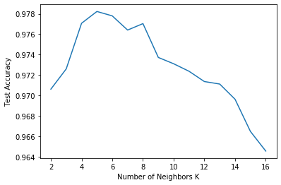

```python
plt.plot(list_k, list_score)
plt.xlabel('Number of Neighbors K')
plt.ylabel('Test Accuracy')
plt.show()
```

```python
knn = KNeighborsRegressor(n_neighbors=5)
knn.fit(X_train, y_train)
```

```
KNeighborsRegressor(algorithm='auto', leaf_size=30, metric='minkowski',
                    metric_params=None, n_jobs=None, n_neighbors=5, p=2,
                    weights='uniform')
```

```python
# Kiểm tra độ chính xác
print("The Train/ Score is: ", knn.score(X_train,y_train)*100,"%")
print("The Test/ Score accuracy is: ", knn.score(X_test,y_test)*100,"%")
```

```
The Train/ Score is:  98.01127110964177 %
The Test/ Score accuracy is:  97.8230348461507 %
```

```python
# Tính MSE
from sklearn import metrics
print('Mean Squared Error:', metrics.mean_squared_error(y_test, y_pred))
```

```
Mean Squared Error: 7451.879581404321
```

Nhận xét:

- Training và Testing cùng có R^2 cao và gần bằng nhau
- Mô hình trên cho R^2 cao ~ 0.98, cho thấy nó fit 98% dữ liệu => mô hình phù hợp

```python
y_pred = knn.predict(X_test)
#y_pred
```

```python
df = pd.DataFrame({'Actual': pd.DataFrame(y_test)[0].values,
                   'Prediction': pd.DataFrame(y_pred)[0].values})
df.head()
```

|  | Actual | Prediction |
| --- | --- | --- |
| 0 | 490 | 450.8 |
| 1 | 548 | 467.6 |
| 2 | 820 | 796.4 |
| 3 | 217 | 198.6 |
| 4 | 491 | 516.4 |

```python
# Xuất model
import pickle
# Save to file in the current working directory
pkl_filename = "NBA_model.pkl"
with open(pkl_filename, 'wb') as file:
    pickle.dump(knn, file)
```

```python
with open(pkl_filename, 'rb') as file:
    nba_model = pickle.load(file)
```

```python
nba_model
```

```
KNeighborsRegressor(algorithm='auto', leaf_size=30, metric='minkowski',
                    metric_params=None, n_jobs=None, n_neighbors=5, p=2,
                    weights='uniform')
```